# Geospatial Risk Prediction

Yingxue Ou

10/20/2022

# Introduction

In this project, I will build spatial variables in “fishnet” raster-like grid and run local Moran’s I as a measure of local clustering. And then, run a poisson regression to predict events measured in counts. Finally, I will compare model performance of Kernal Density as a “business-as-usual” alternative.

## Setup

Begin by loading the requisite packages and functions, including the `functions.R` script.

## Read in Data from Chicago

This uses the `Socrata` package for some data sets. I bring in Weapons Violation(unlawful poss of handgun) data here.

```r
policeDistricts <-
  st_read("https://data.cityofchicago.org/api/geospatial/fthy-xz3r?method=export&format=GeoJSON") %>%
  st_transform('ESRI:102271') %>%
  dplyr::select(District = dist_num)
policeBeats <-
  st_read("https://data.cityofchicago.org/api/geospatial/aerh-rz74?method=export&format=GeoJSON") %>%
  st_transform('ESRI:102271') %>%
  dplyr::select(District = beat_num)
bothPoliceUnits <- rbind(mutate(policeDistricts, Legend = "Police Districts"),
                         mutate(policeBeats, Legend = "Police Beats"))

chicagoBoundary <-
  st_read(file.path(root.dir,"/Chapter5/chicagoBoundary.geojson")) %>%
  st_transform('ESRI:102271')
weapon <-
  read.socrata("https://data.cityofchicago.org/Public-Safety/Crimes-2017/d62x-nvdr") %>%
    filter(Primary.Type == "WEAPONS VIOLATION" & Description == "UNLAWFUL POSS OF HANDGUN") %>%
    mutate(x = gsub("[()]", "", Location)) %>%
    separate(x,into= c("Y","X"), sep=",") %>%
    mutate(X = as.numeric(X),Y = as.numeric(Y)) %>%
    na.omit() %>%
    st_as_sf(coords = c("X", "Y"), crs = 4326, agr = "constant")%>%
    st_transform('ESRI:102271') %>%
    distinct()
```

# 1 A map of outcome of interest in point form

In this section, I present the point map and density map of Weapon Violation in Chicago recorded in 2017.

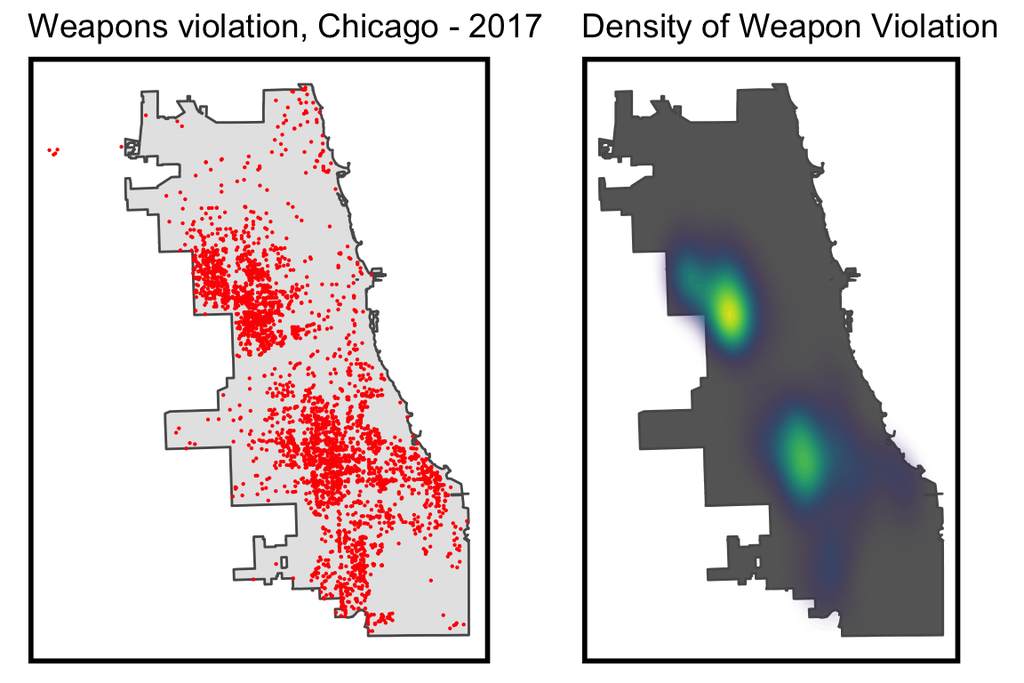

```r
# uses grid.arrange to organize independent plots
grid.arrange(ncol=2,
ggplot() +
  geom_sf(data = chicagoBoundary) +
  geom_sf(data = weapon, colour="red", size=0.1, show.legend = "point") +
  labs(title= "Weapons violation, Chicago - 2017") +
  mapTheme(title_size = 14),

ggplot() +
  geom_sf(data = chicagoBoundary, fill = "grey40") +
  stat_density2d(data = data.frame(st_coordinates(weapon)),
                 aes(X, Y, fill = ..level.., alpha = ..level..),
                 size = 0.01, bins = 40, geom = 'polygon') +
  scale_fill_viridis() +
  scale_alpha(range = c(0.00, 0.35), guide = FALSE) +
  labs(title = "Density of Weapon Violation") +
  mapTheme(title_size = 14) + theme(legend.position = "none"))
```

# 2 A map of outcome joined to the fishnet.

## Creating a fishnet grid

```r
## using {sf} to create the grid
fishnet <-
  st_make_grid(chicagoBoundary,
               cellsize = 500,
               square = TRUE) %>%
  .[chicagoBoundary] %>%            # fast way to select intersecting polygons
  st_sf() %>%
  mutate(uniqueID = 1:n())
```

## Aggregate points to the fishnet

To count the weapons violation by grid cell, first `mutate` a ‘counter’ field, `countWeapon`, for each weapon violation event, and then spatial join (`aggregate`) weapon violation points to the `fishnet`, taking the sum of `countWeapon`. A grid cell with no weapon violation receives `NA` which is converted to `0` with `replace_na`. A random `uniqueID` is generated for each grid cell, as well as a random group `cvID`, used later for cross-validation. Roughly 100 `cvID`s are created to allow 100-fold cross validation. Map below show the counts of weapons violation by grid cell, and the clustered spatial process of weapon violation begins to take shape.

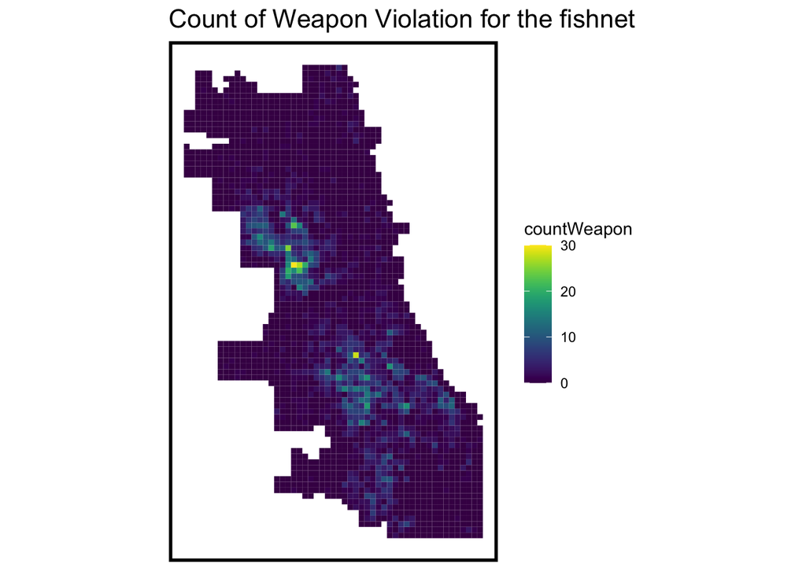

```r
## add a value of 1 to each crime, sum them with aggregate
crime_net <-
  dplyr::select(weapon) %>%
  mutate(countWeapon = 1) %>%
  aggregate(., fishnet, sum) %>%
  mutate(countWeapon = replace_na(countWeapon, 0),
         uniqueID = 1:n(),
         cvID = sample(round(nrow(fishnet) / 24),
                       size=nrow(fishnet), replace = TRUE))

ggplot() +
  geom_sf(data = crime_net, aes(fill = countWeapon), color = NA) +
  scale_fill_viridis() +
  labs(title = "Count of Weapon Violation for the fishnet") +
  mapTheme()
```

# 3 A small multiple map of your risk factors in the fishnet (counts, distance and/or other feature engineering approaches).

## Wrangling risk factors

Here I created a small data set of 8 factor features are downloaded and wrangled to the `fishnet`.

```r
abandonCars <-
  read.socrata("https://data.cityofchicago.org/Service-Requests/311-Service-Requests-Abandoned-Vehicles/3c9v-pnva") %>%na.omit()%>%
    mutate(year = substr(creation_date,1,4)) %>% filter(year == "2017") %>%
    dplyr::select(Y = latitude, X = longitude) %>%
    na.omit() %>%
    st_as_sf(coords = c("X", "Y"), crs = 4326, agr = "constant") %>%
    st_transform(st_crs(fishnet)) %>%
    mutate(Legend = "Abandoned_Cars")

abandonBuildings <-
  read.socrata("https://data.cityofchicago.org/Service-Requests/311-Service-Requests-Vacant-and-Abandoned-Building/7nii-7srd") %>%
    mutate(year = substr(date_service_request_was_received,1,4)) %>%  filter(year == "2017") %>%
    dplyr::select(Y = latitude, X = longitude) %>%
    na.omit() %>%
    st_as_sf(coords = c("X", "Y"), crs = 4326, agr = "constant") %>%
    st_transform(st_crs(fishnet)) %>%
    mutate(Legend = "Abandoned_Buildings")

graffiti <-
  read.socrata("https://data.cityofchicago.org/Service-Requests/311-Service-Requests-Graffiti-Removal-Historical/hec5-y4x5") %>%
    mutate(year = substr(creation_date,1,4)) %>% filter(year == "2017") %>%
    filter(where_is_the_graffiti_located_ %in% c("Front", "Rear", "Side")) %>%
    dplyr::select(Y = latitude, X = longitude) %>%
    na.omit() %>%
    st_as_sf(coords = c("X", "Y"), crs = 4326, agr = "constant") %>%
    st_transform(st_crs(fishnet)) %>%
    mutate(Legend = "Graffiti")

streetLightsOut <-
  read.socrata("https://data.cityofchicago.org/Service-Requests/311-Service-Requests-Street-Lights-All-Out/zuxi-7xem") %>%
    mutate(year = substr(creation_date,1,4)) %>% filter(year == "2017") %>%
    dplyr::select(Y = latitude, X = longitude) %>%
    na.omit() %>%
    st_as_sf(coords = c("X", "Y"), crs = 4326, agr = "constant") %>%
    st_transform(st_crs(fishnet)) %>%
    mutate(Legend = "Street_Lights_Out")

sanitation <-
   read.socrata("https://data.cityofchicago.org/Service-Requests/311-Service-Requests-Sanitation-Code-Complaints-Hi/me59-5fac") %>%
     mutate(year = substr(creation_date,1,4)) %>% filter(year == "2017") %>%
     dplyr::select(Y = latitude, X = longitude) %>%
     na.omit() %>%
     st_as_sf(coords = c("X", "Y"), crs = 4326, agr = "constant") %>%
     st_transform(st_crs(fishnet)) %>%
     mutate(Legend = "Sanitation")

liquorRetail <-
  read.socrata("https://data.cityofchicago.org/resource/nrmj-3kcf.json") %>%
    filter(business_activity == "Retail Sales of Packaged Liquor") %>%
    dplyr::select(Y = latitude, X = longitude) %>%
    na.omit() %>%
    st_as_sf(coords = c("X", "Y"), crs = 4326, agr = "constant") %>%
    st_transform(st_crs(fishnet)) %>%
    mutate(Legend = "Liquor_Retail")

neighborhoods <-
  st_read("https://raw.githubusercontent.com/blackmad/neighborhoods/master/chicago.geojson") %>%
  st_transform(st_crs(fishnet))
# policestations <-
#   st_read("https://data.cityofchicago.org/resource/z8bn-74gv.geojson") %>%
#     dplyr::select(Y = latitude, X = longitude) %>%
#     na.omit() %>%
#     st_as_sf(coords = c("X", "Y"), crs = 4326, agr = "constant") %>%
#     st_transform(st_crs(fishnet)) %>%
#     mutate(Legend = "PoliceStations")
#
# BuildingViolation <-
#   read.socrata("https://data.cityofchicago.org/resource/22u3-xenr.json") %>%
#     mutate(year = substr(creation_date,1,4)) %>% filter(year == "2017") %>%
#     dplyr::select(Y = latitude, X = longitude) %>%
#     na.omit() %>%
#     st_as_sf(coords = c("X", "Y"), crs = 4326, agr = "constant") %>%
#     st_transform(st_crs(fishnet)) %>%
#     mutate(Legend = "BuildingViolation")
#
# Arrests <-
#   read.socrata("https://data.cityofchicago.org/resource/dpt3-jri9.json") %>%
#     mutate(year = substr(creation_date,1,4)) %>% filter(year == "2017") %>%
#     dplyr::select(Y = latitude, X = longitude) %>%
#     na.omit() %>%
#     st_as_sf(coords = c("X", "Y"), crs = 4326, agr = "constant") %>%
#     st_transform(st_crs(fishnet)) %>%
#     mutate(Legend = "Arrests")

alleyLightsOut <-
  read.socrata("https://data.cityofchicago.org/resource/up7z-t43p.json") %>%
    mutate(year = substr(creation_date,1,4)) %>% filter(year == "2017") %>%
    dplyr::select(Y = latitude, X = longitude) %>%
    na.omit() %>%
    st_as_sf(coords = c("X", "Y"), crs = 4326, agr = "constant") %>%
    st_transform(st_crs(fishnet)) %>%
    mutate(Legend = "AlleyLightsOut")

rodentBait <-
  read.socrata("https://data.cityofchicago.org/resource/uqhs-j723.json") %>%
    mutate(year = substr(creation_date,1,4)) %>% filter(year == "2017") %>%
    dplyr::select(Y = latitude, X = longitude) %>%
    na.omit() %>%
    st_as_sf(coords = c("X", "Y"), crs = 4326, agr = "constant") %>%
    st_transform(st_crs(fishnet)) %>%
    mutate(Legend = "RodentBaiting")
```

## Count of risk factor by grid cell

Here I joined a long form of layer of crime events to the `vars_net` fishnet.

```r
vars_net <-
  rbind(abandonCars,streetLightsOut,abandonBuildings,
        liquorRetail, alleyLightsOut, rodentBait, graffiti, sanitation) %>%
  st_join(., fishnet, join=st_within) %>%
  st_drop_geometry() %>%
  group_by(uniqueID, Legend) %>%
  summarize(count = n()) %>%
    full_join(fishnet) %>%
    spread(Legend, count, fill=0) %>%
    st_sf() %>%
    dplyr::select(-`<NA>`) %>%
    na.omit() %>%
    ungroup()
```

The risk factors by fishnet are plotted below.

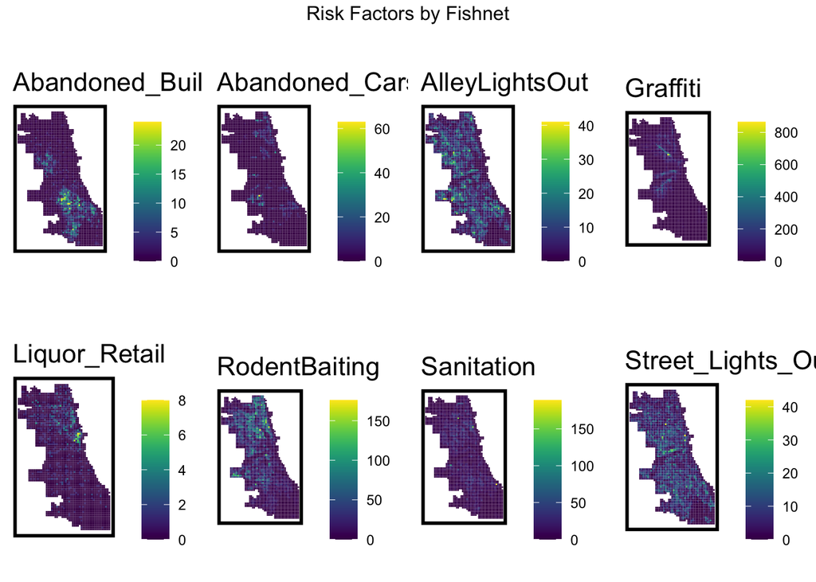

```r
vars_net.long <-
  gather(vars_net, Variable, value, -geometry, -uniqueID)

vars <- unique(vars_net.long$Variable)
mapList <- list()

for(i in vars){
  mapList[[i]] <-
    ggplot() +
      geom_sf(data = filter(vars_net.long, Variable == i), aes(fill=value), colour=NA) +
      scale_fill_viridis(name="") +
      labs(title=i) +
      mapTheme()}

do.call(grid.arrange,c(mapList, ncol=4, top="Risk Factors by Fishnet"))
```

# 4 Local Moran’s I-related small multiple map of your outcome (see 5.4.1)

## Creating final_net

Next, the `crime_net` and `vars_net` layers are joined into one regression-ready, `final_net`.

```r
## important to drop the geometry from joining features
final_net <-
  left_join(crime_net, st_drop_geometry(vars_net), by="uniqueID")
```

## Join in areal data

Neighborhood `name` and `policeDistrict` are spatially joined to the `final_net` using grid cell centroids.

```r
final_net <-
  st_centroid(final_net) %>%
    st_join(dplyr::select(neighborhoods, name), by = "uniqueID") %>%
    st_join(dplyr::select(policeDistricts, District), by = "uniqueID") %>%
      st_drop_geometry() %>%
      left_join(dplyr::select(final_net, geometry, uniqueID)) %>%
      st_sf() %>%
  na.omit()
```

## Local Moran’s I

Here I use {spdep} package to to build neighborhood weights and list to calculate local Moran’s I.

```r
final_net.nb <- poly2nb(as_Spatial(final_net), queen=TRUE)

final_net.weights <- nb2listw(final_net.nb, style="W", zero.policy=TRUE)
```

```r
## see ?localmoran
local_morans <- localmoran(final_net$countWeapon, final_net.weights, zero.policy=TRUE) %>%
  as.data.frame()

# join local Moran's I results to fishnet
final_net.localMorans <-
  cbind(local_morans, as.data.frame(final_net)) %>%
  st_sf() %>%
  dplyr::select(countWeapon = countWeapon,
                Local_Morans_I = Ii,
                P_Value = `Pr(z != E(Ii))`) %>%
  mutate(Significant_Hotspots = ifelse(P_Value <= 0.001, 1, 0)) %>%
  gather(Variable, Value, -geometry)
```

## Plotting local Moran’s I results

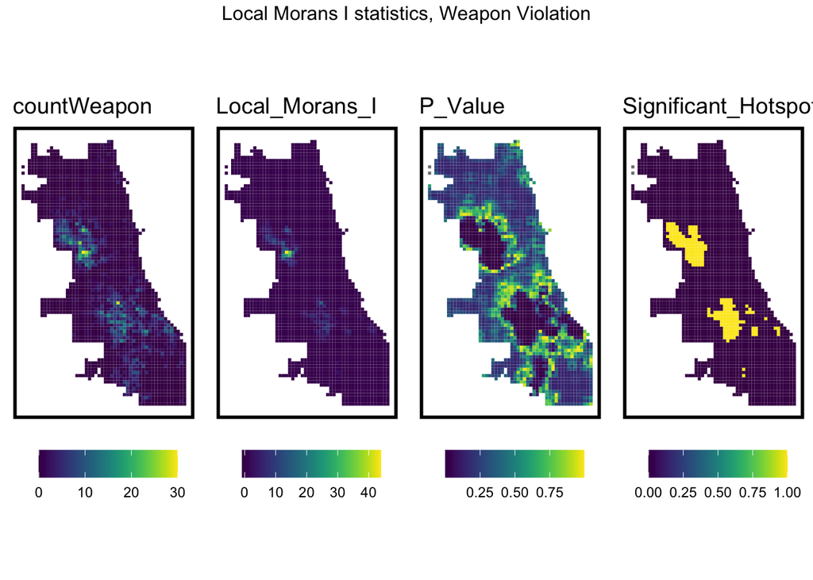

```r
## This is just for plotting
vars <- unique(final_net.localMorans$Variable)
varList <- list()

for(i in vars){
  varList[[i]] <-
    ggplot() +
      geom_sf(data = filter(final_net.localMorans, Variable == i),
              aes(fill = Value), colour=NA) +
      scale_fill_viridis(name="") +
      labs(title=i) +
      mapTheme(title_size = 14) + theme(legend.position="bottom")}

do.call(grid.arrange,c(varList, ncol = 4, top = "Local Morans I statistics, Weapon Violation"))
```

# 5 A small multiple scatterplot with correlations

In this section, I present a small multiple scatterplot of `countWeapon` as a function of the risk factors.

```r
loopPoint <-
  filter(neighborhoods, name == "Loop") %>%
  st_centroid()

vars_net$loopDistance =
  st_distance(st_centroid(vars_net),loopPoint) %>%
  as.numeric()
```

```r
final_net <-
  left_join(crime_net, st_drop_geometry(vars_net), by="uniqueID")

final_net <-
  st_centroid(final_net) %>%
    st_join(dplyr::select(neighborhoods, name)) %>%
    st_join(dplyr::select(policeDistricts, District)) %>%
      st_drop_geometry() %>%
      left_join(dplyr::select(final_net, geometry, uniqueID)) %>%
      st_sf() %>%
  na.omit()
```

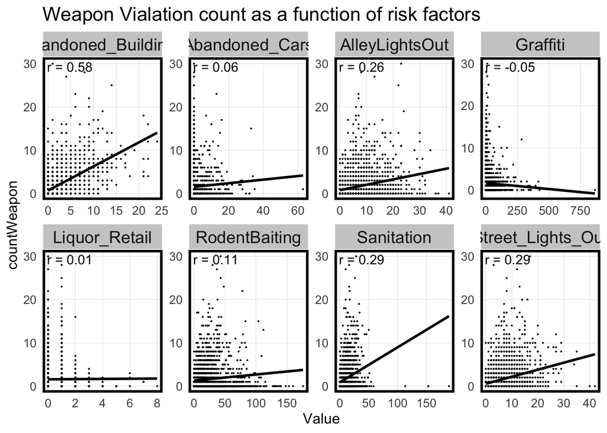

```r
correlation.long <-
  st_drop_geometry(final_net) %>%
    dplyr::select(-uniqueID, -cvID, -loopDistance, -name, -District) %>%
    gather(Variable, Value, -countWeapon)

correlation.cor <-
  correlation.long %>%
    group_by(Variable) %>%
    summarize(correlation = cor(Value, countWeapon, use = "complete.obs"))

ggplot(correlation.long, aes(Value, countWeapon)) +
  geom_point(size = 0.1) +
  geom_text(data = correlation.cor, aes(label = paste("r =", round(correlation, 2))),
            x=-Inf, y=Inf, vjust = 1.5, hjust = -.1) +
  geom_smooth(method = "lm", se = FALSE, colour = "black") +
  facet_wrap(~Variable, ncol = 4, scales = "free") +
  labs(title = "Weapon Vialation count as a function of risk factors") +
  plotTheme()
```

# 6 A histogram of dependent variable

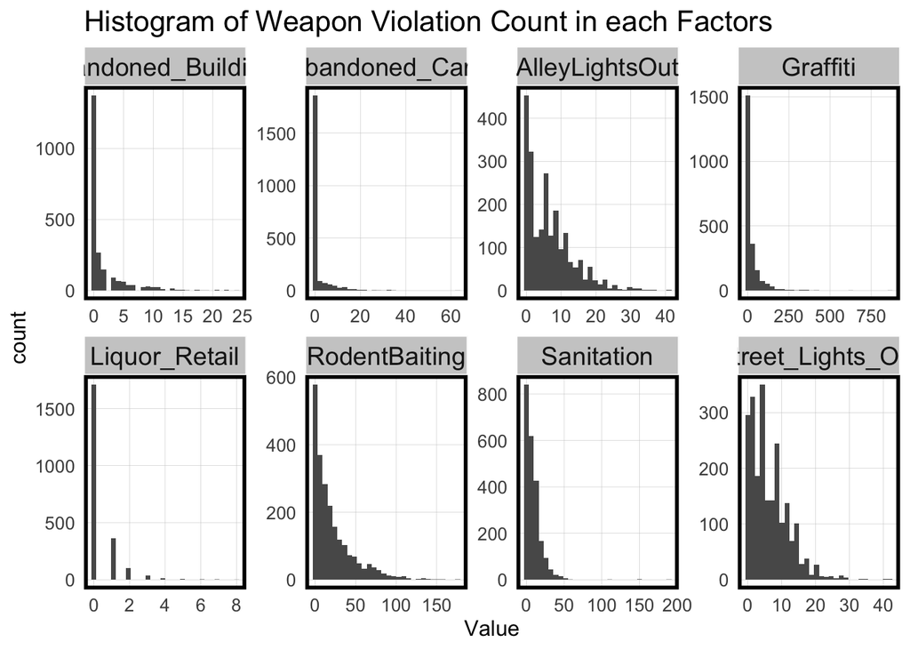

```r
ggplot(correlation.long)+
  geom_histogram(aes(Value)) +
  facet_wrap(~Variable, ncol = 4, scales = "free") +
  labs(title = "Histogram of Weapon Violation Count in each Factors") +
  plotTheme()
```

Then, I plot the histogram of dependent variable `countWeapon`.

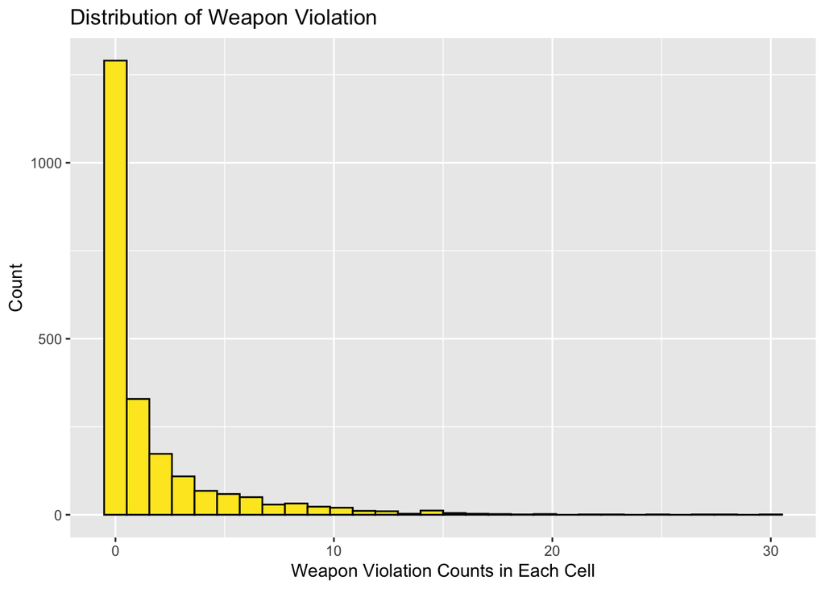

```r
ddd <- ggplot(final_net, aes(x =countWeapon)) +
  geom_histogram(bins = 30, colour="black", fill = "#FDE725FF") +
    labs(title="Distribution of Weapon Violation",
         x="Weapon Violation Counts in Each Cell", y="Count")

ddd
```

# 7 Map of model errors by random k-fold and spatial cross validation

## Join NN feature to our fishnet

Here I calculated NN of each variable by setting K=3.

```r
# nearest neighborhood features

st_c <- st_coordinates
st_coid <- st_centroid

final_net <-
  final_net %>%
  mutate(
    Abandoned_Buildings.nn =
      nn_function(st_c(st_coid(final_net)), st_c(abandonBuildings), 3),
    Abandoned_Cars.nn =
      nn_function(st_c(st_coid(final_net)), st_c(abandonCars), 3),
    AlleyLightsOut.nn =
      nn_function(st_c(st_coid(final_net)), st_c(alleyLightsOut), 3),
    Liquor_Retail.nn =
      nn_function(st_c(st_coid(final_net)), st_c(liquorRetail), 3),
    RodentBaiting.nn =
      nn_function(st_c(st_coid(final_net)), st_c(rodentBait), 3),
    Street_Lights_Out.nn =
      nn_function(st_c(st_coid(final_net)), st_c(streetLightsOut), 3),
    Sanitation.nn =
        nn_function(st_c(st_coid(final_net)), st_c(sanitation),3),
    Graffiti.nn =
        nn_function(st_c(st_coid(final_net)), st_c(graffiti),3))
```

Using NN distance to a hot spot location of each variables.

```r
 # generates warning from NN
final_net <- final_net %>%
  mutate(weapon.isSig =
           ifelse(local_morans[,5] <= 0.001, 1, 0)) %>%
  mutate(weapon.isSig.dist =
           nn_function(st_c(st_coid(final_net)),
                       st_c(st_coid(filter(final_net,
                                           weapon.isSig == 1))),
                       k = 1))
```

```r
reg.vars <- c("Abandoned_Buildings.nn", "Abandoned_Cars.nn", "AlleyLightsOut.nn",
              "Liquor_Retail.nn", "Street_Lights_Out.nn", "RodentBaiting.nn",
              "Sanitation.nn", "Graffiti.nn",
              "loopDistance")

reg.ss.vars <- c("Abandoned_Buildings.nn", "Abandoned_Cars.nn", "AlleyLightsOut.nn",
                 "Liquor_Retail.nn", "Street_Lights_Out.nn", "RodentBaiting.nn",
                 "Sanitation.nn", "Graffiti.nn",
                 "loopDistance", "weapon.isSig", "weapon.isSig.dist")
```

I generated four regressions below - two including `Just Risk Factors(reg.vars)`, and a second (`reg.ss.vars`) includes risk factors plus the Local Moran’s I `Spatial Process` features created above.

```r
reg.cv <- crossValidate(
  dataset = final_net,
  id = "cvID",
  dependentVariable = "countWeapon",
  indVariables = reg.vars) %>%
    dplyr::select(cvID = cvID, countWeapon, Prediction, geometry)

reg.ss.cv <- crossValidate(
  dataset = final_net,
  id = "cvID",
  dependentVariable = "countWeapon",
  indVariables = reg.ss.vars) %>%
    dplyr::select(cvID = cvID, countWeapon, Prediction, geometry)

reg.spatialCV <- crossValidate(
  dataset = final_net,
  id = "name",
  dependentVariable = "countWeapon",
  indVariables = reg.vars) %>%
    dplyr::select(cvID = name, countWeapon, Prediction, geometry)

reg.ss.spatialCV <- crossValidate(
  dataset = final_net,
  id = "name",
  dependentVariable = "countWeapon",
  indVariables = reg.ss.vars) %>%
    dplyr::select(cvID = name, countWeapon, Prediction, geometry)
```

```r
reg.summary <-
  rbind(
    mutate(reg.cv,           Error = Prediction - countWeapon,
                             Regression = "Random k-fold CV: Just Risk Factors"),

    mutate(reg.ss.cv,        Error = Prediction - countWeapon,
                             Regression = "Random k-fold CV: Spatial Process"),

    mutate(reg.spatialCV,    Error = Prediction - countWeapon,
                             Regression = "Spatial LOGO-CV: Just Risk Factors"),

    mutate(reg.ss.spatialCV, Error = Prediction - countWeapon,
                             Regression = "Spatial LOGO-CV: Spatial Process")) %>%
    st_sf()
```

In the code block below, `error_by_reg_and_fold` calculates and visualizes MAE for each fold across each regression. The `Spatial Process` features seem to reduce errors overall.

```r
error_by_reg_and_fold <-
  reg.summary %>%
    group_by(Regression, cvID) %>%
    summarize(Mean_Error = mean(Prediction - countWeapon, na.rm = T),
              MAE = mean(abs(Mean_Error), na.rm = T),
              SD_MAE = mean(abs(Mean_Error), na.rm = T)) %>%
  ungroup()
```

Plot a multiple map of model errors

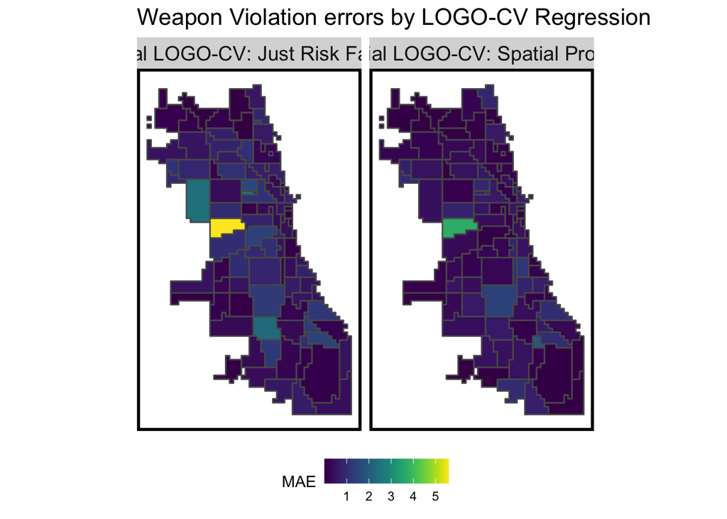

```r
error_by_reg_and_fold %>%
  filter(str_detect(Regression, "LOGO")) %>%
  ggplot() +
    geom_sf(aes(fill = MAE)) +
    facet_wrap(~Regression) +
    scale_fill_viridis() +
    labs(title = "Weapon Violation errors by LOGO-CV Regression") +
    mapTheme() + theme(legend.position="bottom")
```

# 8 A table of MAE and standard deviation MAE by regression.

Here I present the distributions of MAE of both k-fold cross validation and LOGO-CV.

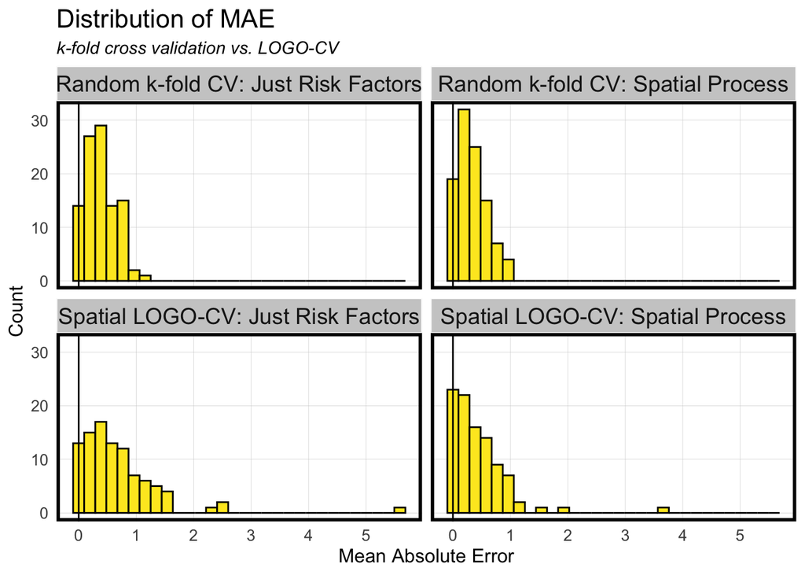

```r
error_by_reg_and_fold %>%
  ggplot(aes(MAE)) +
    geom_histogram(bins = 30, colour="black", fill = "#FDE725FF") +
    facet_wrap(~Regression) +
    geom_vline(xintercept = 0) + scale_x_continuous(breaks = seq(0, 8, by = 1)) +
    labs(title="Distribution of MAE", subtitle = "k-fold cross validation vs. LOGO-CV",
         x="Mean Absolute Error", y="Count") +
    plotTheme()
```

```r
st_drop_geometry(error_by_reg_and_fold) %>%
  group_by(Regression) %>%
    summarize(Mean_MAE = round(mean(MAE), 2),
              SD_MAE = round(sd(MAE), 2)) %>%
  kable() %>%
    kable_styling("striped", full_width = F) %>%
    row_spec(2, color = "black", background = "#FDE725FF") %>%
    row_spec(4, color = "black", background = "#FDE725FF")
```

| Regression | Mean_MAE | SD_MAE |
| --- | --- | --- |
| Random k-fold CV: Just Risk Factors | 0.38 | 0.26 |
| Random k-fold CV: Spatial Process | 0.33 | 0.25 |
| Spatial LOGO-CV: Just Risk Factors | 0.68 | 0.73 |
| Spatial LOGO-CV: Spatial Process | 0.45 | 0.49 |

# 9 A table of raw errors by race context

To test if the algorithm generalize across different neighborhood contexts, I used `tidycensus` to pull race data by Census tract. `percentWhite` is calculated and tracts are split into two groups, `Majority_White` and `Majority_Non_White`. A spatial subset is used to get tracts within the study area.

```r
tracts18 <-
  get_acs(geography = "tract", variables = c("B01001_001E","B01001A_001E"),
          year = 2018, state=17, county=031, geometry=T) %>%
  st_transform('ESRI:102271')  %>%
  dplyr::select(variable, estimate, GEOID) %>%
  spread(variable, estimate) %>%
  rename(TotalPop = B01001_001,
         NumberWhites = B01001A_001) %>%
  mutate(percentWhite = NumberWhites / TotalPop,
         raceContext = ifelse(percentWhite > .5, "Majority_White", "Majority_Non_White")) %>%
  .[neighborhoods,]
reg.summary %>%
  filter(str_detect(Regression, "LOGO")) %>%
    st_centroid() %>%
    st_join(tracts18) %>%
    na.omit() %>%
      st_drop_geometry() %>%
      group_by(Regression, raceContext) %>%
      summarize(mean.Error = mean(Error, na.rm = T)) %>%
      spread(raceContext, mean.Error) %>%
      kable(caption = "Mean Error by neighborhood racial context") %>%
        kable_styling("striped", full_width = F)
```

Mean Error by neighborhood racial context

| Regression | Majority_Non_White | Majority_White |
| --- | --- | --- |
| Spatial LOGO-CV: Just Risk Factors | -0.353945 | 0.3439122 |
| Spatial LOGO-CV: Spatial Process | -0.090710 | 0.0942107 |

It looks like this algorithm generalizes well with respect to race.

# 10 The map comparing kernel density to risk predictions for the next year’s crime.

Maps below shows Kernel density at three different scales.

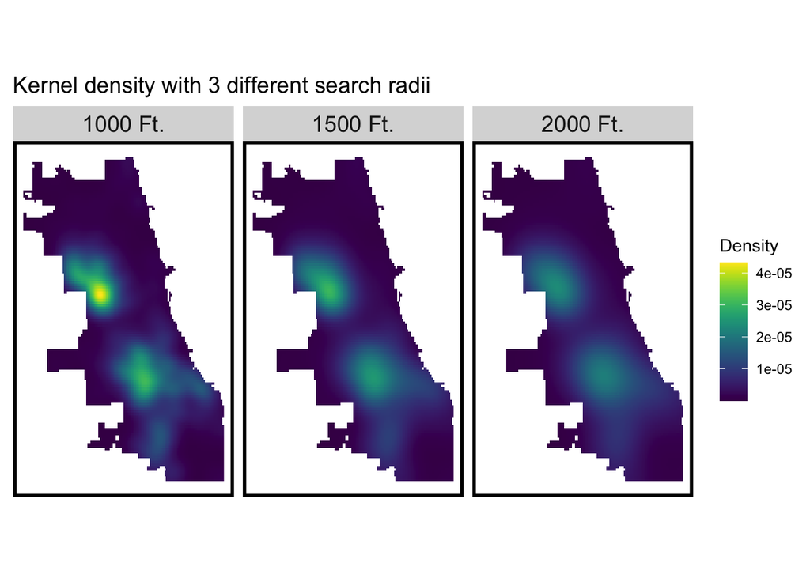

```r
weapon_ppp <- as.ppp(st_coordinates(weapon), W = st_bbox(final_net))
weapon_KD.1000 <- spatstat.core::density.ppp(weapon_ppp, 1000)
weapon_KD.1500 <- spatstat.core::density.ppp(weapon_ppp, 1500)
weapon_KD.2000 <- spatstat.core::density.ppp(weapon_ppp, 2000)
weapon_KD.df <- rbind(
  mutate(data.frame(rasterToPoints(mask(raster(weapon_KD.1000), as(neighborhoods, 'Spatial')))), Legend = "1000 Ft."),
  mutate(data.frame(rasterToPoints(mask(raster(weapon_KD.1500), as(neighborhoods, 'Spatial')))), Legend = "1500 Ft."),
  mutate(data.frame(rasterToPoints(mask(raster(weapon_KD.2000), as(neighborhoods, 'Spatial')))), Legend = "2000 Ft."))

weapon_KD.df$Legend <- factor(weapon_KD.df$Legend, levels = c("1000 Ft.", "1500 Ft.", "2000 Ft."))

ggplot(data=weapon_KD.df, aes(x=x, y=y)) +
  geom_raster(aes(fill=layer)) +
  facet_wrap(~Legend) +
  coord_sf(crs=st_crs(final_net)) +
  scale_fill_viridis(name="Density") +
  labs(title = "Kernel density with 3 different search radii") +
  mapTheme(title_size = 14)
```

Now, create a Kernel density map with a `1000ft` search redius using the `spatstat` package. `as.ppp` converts burglary coordinates to a `ppp` class. The `density` function creates the Kernel density. To map, the `ppp` is converted to a data frame and then an `sf` layer. Points are spatially joined to the `final_net` and the mean density is taken. Here density is visualized with a `sample_n` of 1,500 points overlayed on top.

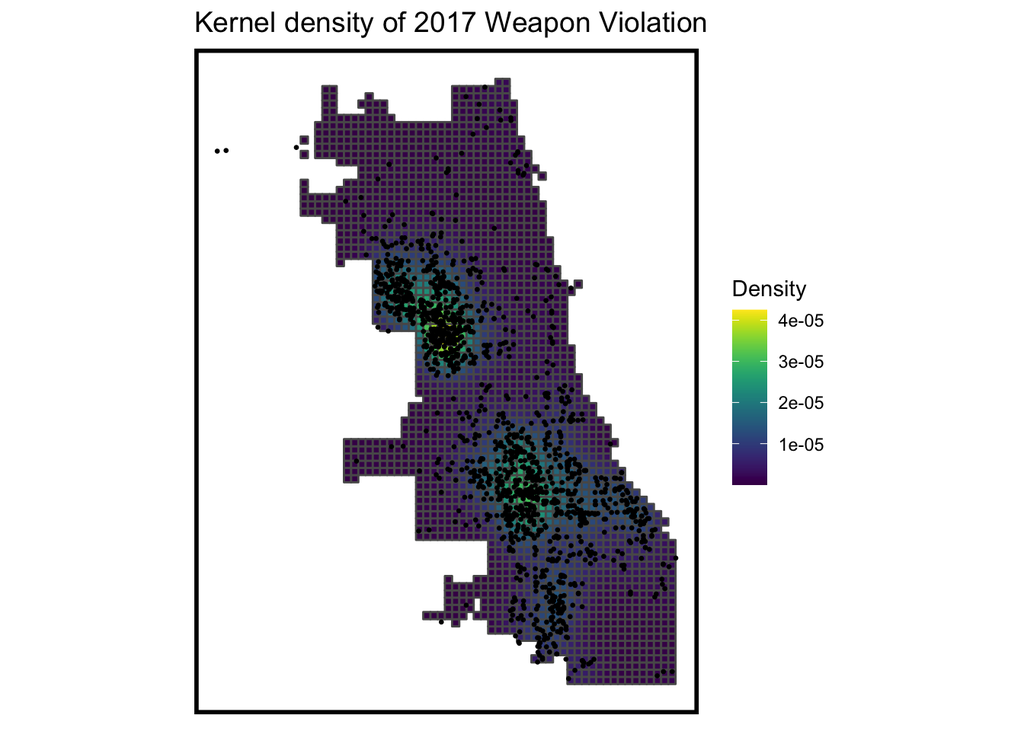

```r
as.data.frame(weapon_KD.1000) %>%
  st_as_sf(coords = c("x", "y"), crs = st_crs(final_net)) %>%
  aggregate(., final_net, mean) %>%
   ggplot() +
     geom_sf(aes(fill=value)) +
     geom_sf(data = sample_n(weapon, 1500), size = .5) +
     scale_fill_viridis(name = "Density") +
     labs(title = "Kernel density of 2017 Weapon Violation") +
     mapTheme(title_size = 14)
```

```r
weapon18 <-
  read.socrata("https://data.cityofchicago.org/Public-Safety/Crimes-2018/3i3m-jwuy") %>%
  filter(Primary.Type == "WEAPONS VIOLATION" &
         Description == "UNLAWFUL POSS OF HANDGUN") %>%
  mutate(x = gsub("[()]", "", Location)) %>%
  separate(x,into= c("Y","X"), sep=",") %>%
  mutate(X = as.numeric(X),
         Y = as.numeric(Y)) %>%
  na.omit %>%
  st_as_sf(coords = c("X", "Y"), crs = 4326, agr = "constant") %>%
  st_transform('ESRI:102271') %>%
  distinct() %>%
  .[fishnet,]
```

```r
weapon_KDE_sum <- as.data.frame(weapon_KD.1000) %>%
  st_as_sf(coords = c("x", "y"), crs = st_crs(final_net)) %>%
  aggregate(., final_net, mean)
kde_breaks <- classIntervals(weapon_KDE_sum$value,
                             n = 5, "fisher")
weapon_KDE_sf <- weapon_KDE_sum %>%
  mutate(label = "Kernel Density",
         Risk_Category = classInt::findCols(kde_breaks),
         Risk_Category = case_when(
           Risk_Category == 5 ~ "5th",
           Risk_Category == 4 ~ "4th",
           Risk_Category == 3 ~ "3rd",
           Risk_Category == 2 ~ "2nd",
           Risk_Category == 1 ~ "1st")) %>%
  cbind(
    aggregate(
      dplyr::select(weapon18) %>% mutate(weaponCount = 1), ., sum) %>%
    mutate(weaponCount = replace_na(weaponCount, 0))) %>%
  dplyr::select(label, Risk_Category, weaponCount)
```

Here I pull a model out of a list of models I’ve created.

```r
ml_breaks <- classIntervals(reg.ss.spatialCV$Prediction,
                             n = 5, "fisher")
weapon_risk_sf <-
  reg.ss.spatialCV %>%
  mutate(label = "Risk Predictions",
         Risk_Category =classInt::findCols(ml_breaks),
         Risk_Category = case_when(
           Risk_Category == 5 ~ "5th",
           Risk_Category == 4 ~ "4th",
           Risk_Category == 3 ~ "3rd",
           Risk_Category == 2 ~ "2nd",
           Risk_Category == 1 ~ "1st")) %>%
  cbind(
    aggregate(
      dplyr::select(weapon18) %>% mutate(weaponCount = 1), ., sum) %>%
      mutate(weaponCount = replace_na(weaponCount, 0))) %>%
  dplyr::select(label,Risk_Category, weaponCount)
```

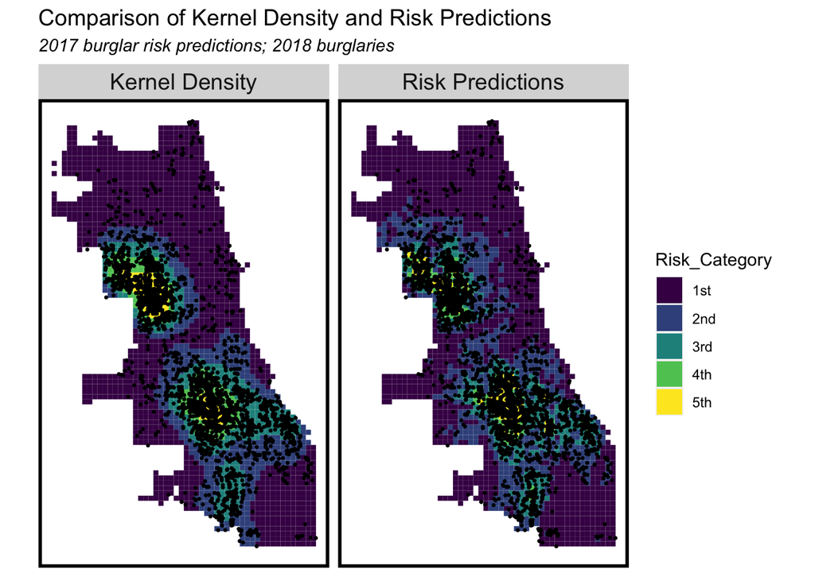

```r
rbind(weapon_KDE_sf, weapon_risk_sf) %>%
  na.omit() %>%
  gather(Variable, Value, -label, -Risk_Category, -geometry) %>%
  ggplot() +
    geom_sf(aes(fill = Risk_Category), colour = NA) +
    geom_sf(data = sample_n(weapon18, 3000), size = .5, colour = "black") +
    facet_wrap(~label, ) +
    scale_fill_viridis(discrete = TRUE) +
    labs(title="Comparison of Kernel Density and Risk Predictions",
         subtitle="2017 burglar risk predictions; 2018 burglaries") +
    mapTheme(title_size = 14)
```

Maps above illustrate that the 2017 kernel density and risk predictions is very similar with that in 2018.

# 11 The bar plot making this comparison.

Finally, the code block below calculates the rate of 2018 weapons violation points by risk category and model type. A well fit model should show that the risk predictions capture a greater share of 2018 burglaries in the middle risk category relative to the Kernel density.

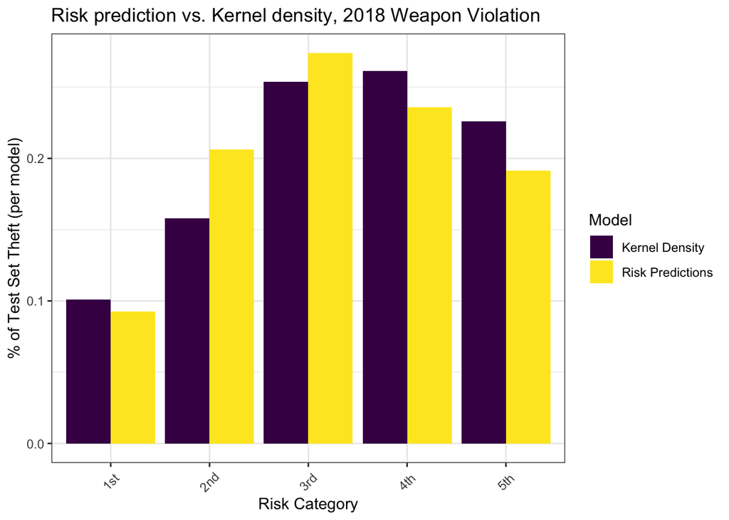

```r
rbind(weapon_KDE_sf, weapon_risk_sf) %>%
  st_drop_geometry() %>%
  na.omit() %>%
  gather(Variable, Value, -label, -Risk_Category) %>%
  group_by(label, Risk_Category) %>%
  summarize(weaponCount = sum(Value)) %>%
  ungroup() %>%
  group_by(label) %>%
  mutate(Pcnt_of_test_set_crimes = weaponCount / sum(weaponCount)) %>%
    ggplot(aes(Risk_Category,Pcnt_of_test_set_crimes)) +
      geom_bar(aes(fill=label), position="dodge", stat="identity") +
      scale_fill_viridis(discrete = TRUE, name = "Model") +
      labs(title = "Risk prediction vs. Kernel density, 2018 Weapon Violation",
           y = "% of Test Set Theft (per model)",
           x = "Risk Category") +
  theme_bw() +
      theme(axis.text.x = element_text(angle = 45, vjust = 0.5))
```

# 12 Two paragraphs on why or why not you would recommend your algorithm be put into production.

In conclusion, I would like to recommend my algorithm be put into production. The geospatial risk prediction model borrows the weapon violation in places where it has benn observed, and tests whether that experience generalizes to places where weapons violation risk may be middle high. If these tests are successful, the results predictions can be thought of as ‘latent risk’ for weapons violation and can be used to allocate police response.

By introducing new features engineering stratrgies to capture the local spatial process and spatial cross-validation as an important test of across-space generalizability. It is believed that even a simple risk prediction algorithm may outperform traditional hot spot analysis. By adding the element of time/seasonality and deploying predictions in an intuitive user interface, this approach could have better competitive in commercial predictive policing products.